# Projeto Integrador

Grupo 2 - Arnaldo, Daniel, Giovanna, Caetano

2023-09-11

# 1. Descrição do problema e análise das métricas de desempenho

Esta etapa do projeto tem como objetivo desenvolver modelos de classificação para determinar se uma empresa encerrará suas atividades em até dois anos. Os dados usados foram coletados pela Bisnode, uma empresa europeia especializada em informações empresariais, e pré-processados pelo nosso grupo em python.

Foi utilizado os modelos de Regressão Logística, Ridge, Lasso, Elastic-net, Random Forest e XGBOOST para realizar a modelagem de classificação das empresas.

Decidimos utilizar a AUC-ROC para medir e comparar a performance dos modelos dado sua capacidade de equilibrar sensibilidade e especificidade, resistir ao desbalanceamento de classes e proporcionar uma interpretação intuitiva da capacidade do modelo, tornando-a uma métrica abrangente e facilmente compreensível.

Após a escolha final do modelo, rodamos também uma matriz de confusão do modelo escolhido para diferentes thresholds, de forma a avaliar diferentes métricas como acuracidade total, Sensibilidade, Especificidade, Valores Preditos Positivos (PPV) e Valores Preditos Negativos (NPV) de forma a possibilitar a definição final do threshold do modelo que melhor atingiria os possíveis objetivos de negócio ao se implementar este modelo.

# 2. Input da Base e ajustes básicos

```r
df <- read.csv("C:/Users/arnch/OneDrive/Documentos/Insper/projeto_integrador/base_modelo_v03.csv")
df %>% head(5)  %>% glimpse()
```

```
## Rows: 5
## Columns: 46
## $ extra_profit_loss    <dbl> 0.000, 0.000, 0.000, 7.407, 11.111
## $ inc_bef_tax          <dbl> -7696, 11819, 96752, -1430, -1096
## $ profit_loss_year     <dbl> -7722, 9722, 96752, -2352, -1107
## $ share_eq             <dbl> 191263, 93144, 1071011, 309885, 10781
## $ subscribed_cap       <dbl> 200741, 11111, 17481, 11111, 11111
## $ balsheet_length      <int> 365, 365, 365, 365, 365
## $ balsheet_notfullyear <int> 0, 0, 0, 0, 0
## $ ceo_count            <dbl> 1, 2, 1, 1, 2
## $ foreign              <dbl> 0, 0, 0, 0, 0
## $ female               <dbl> 0.0, 0.0, 0.0, 0.0, 0.5
## $ inoffice_days        <dbl> 3222, 3101, 6198, 3594, 1246
## $ flag                 <int> 0, 0, 0, 0, 0
## $ birth_year_flag      <int> 0, 0, 0, 0, 0
```

[output cut: 33 more lines]

### Visualização da variável objetivo

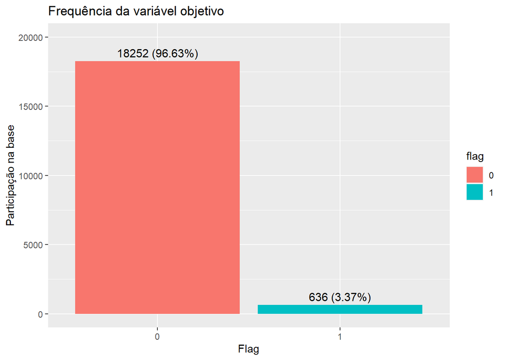

Apenas 3.37% das empresas da base, no ano de 2012, estão com o flag para indicar que irão encerrar suas operações nos próximos 2 anos.

# 3. Split da base em treino e teste

Iremos separar a base em treino e teste, mantendo a proporção da variável resposta (flag). Adicionalmente, faremos as transformações destas bases para input nos modelos glmnet e xgboost

```r
#split inicial da base em 80% para treino
set.seed(123)
splits <- initial_split(df, prop = .8, strata = 'flag')
tr   <- training(splits)
test <- testing(splits)

# Transformação em matrix para glmnet
X_tr <- model.matrix(flag ~ ., tr)[,-1]
y_tr <- tr$flag
X_test <- model.matrix(flag ~ ., test)[,-1]
y_test <- test$flag

# Transformação para matrix XGBM
tr_XGBM <- tr
test_XGBM <- test
tr_XGBM$flag <- ifelse(tr_XGBM$flag == "1", 1, 0)
test_XGBM$flag <- ifelse(test_XGBM$flag == "1", 1, 0)
```

# 4. Criação do Tibble de Comparativo de Desempenho

Agora iremos criar um tibble para armazenar os resultados dos modelos

```r
desempenho <- tibble(
  prob = numeric(0),                 # número decimal
  classes = factor(character(0)),    # fator
  metodo = factor(character(0))      # fator
)
```

# 5. Modelos

- Foram selecionados algumas classes de modelos para realizarmos a classificação dos dados:
  1. Regressão Logistica
  2. Modelos Regularizados (Ridge, LASSO, Elastic-Net)
  3. Random Forest - ranger
  4. Extreme Gradient Boosting - XGBoost

## 5.1 Regressão Logística

```r
# Fit do modelo logístico
logistic_model2 <- glm(flag ~ ., data = tr, family = "binomial")


# Predições do modelo logístico
predictions_LM2 <- as.vector(predict(logistic_model2, newdata = test, type = "response"))

# Salvando vetor de previsões no tibble desempenho
desempenho <- desempenho %>%
  bind_rows(tibble(prob = predictions_LM2,
                   classes = ifelse(y_test == "1", "Yes", "No"),
                   metodo = "Reg_Log"))

# Calculo do AUC
desempenho %>%
  mutate(classes = factor(classes)) %>%
  group_by(metodo) %>%
  roc_auc(classes, prob, event_level = "second") %>%
  arrange(desc(.estimate))
```

```
## # A tibble: 1 × 4
##   metodo  .metric .estimator .estimate
##   <chr>   <chr>   <chr>          <dbl>
## 1 Reg_Log roc_auc binary         0.840
```

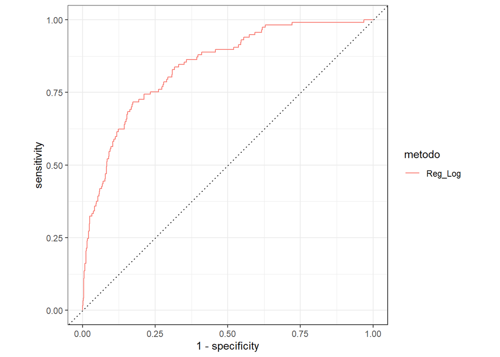

```r
# Construção da curva ROC
desempenho %>%
  mutate(classes = factor(classes)) %>%
  group_by(metodo) %>%
  roc_curve(classes, prob, event_level = "second") %>%
  autoplot()
```

```r
#visualizando os coeficientes e a regressão
#summary(logistic_model2)
```

## 5.2 Modelos Regularizados

### Ridge

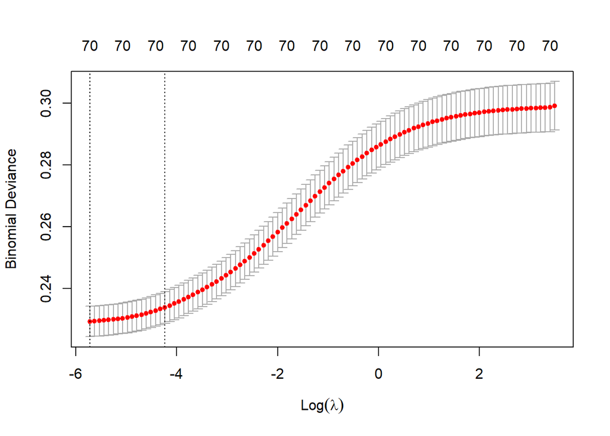

```r
set.seed(123)
fit <- glmnet(X_tr,y_tr, family='binomial',alpha = 0)
#plot_glmnet(fit)

cv_ridge <- cv.glmnet(X_tr, y_tr, alpha = 0, family = "binomial")
plot(cv_ridge)
```

```r
s <- cv_ridge$lambda.1se

prob_ridge <- as.vector(predict(fit, newx = X_test, type = "response", s = s))

desempenho <- desempenho %>%
  bind_rows(tibble(prob = prob_ridge,
                     classes = ifelse(test$flag == "1", "Yes", "No"),
                     metodo = "Ridge"))

desempenho %>%
  mutate(classes = factor(classes)) %>%
  group_by(metodo) %>%
  roc_auc(classes, prob, event_level = "second") %>%
  arrange(desc(.estimate))
```

```
## # A tibble: 2 × 4
##   metodo  .metric .estimator .estimate
##   <chr>   <chr>   <chr>          <dbl>
## 1 Ridge   roc_auc binary         0.850
## 2 Reg_Log roc_auc binary         0.840
```

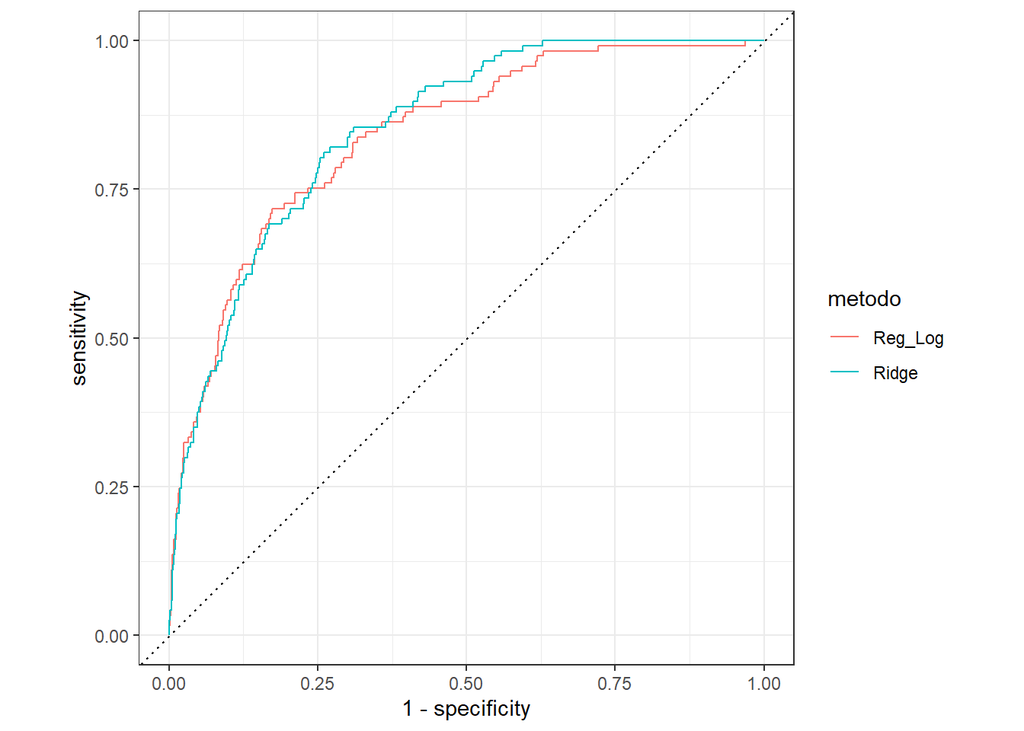

```r
desempenho %>%
  mutate(classes = factor(classes)) %>%
  group_by(metodo) %>%
  roc_curve(classes, prob, event_level = "second") %>%
  autoplot()
```

### LASSO

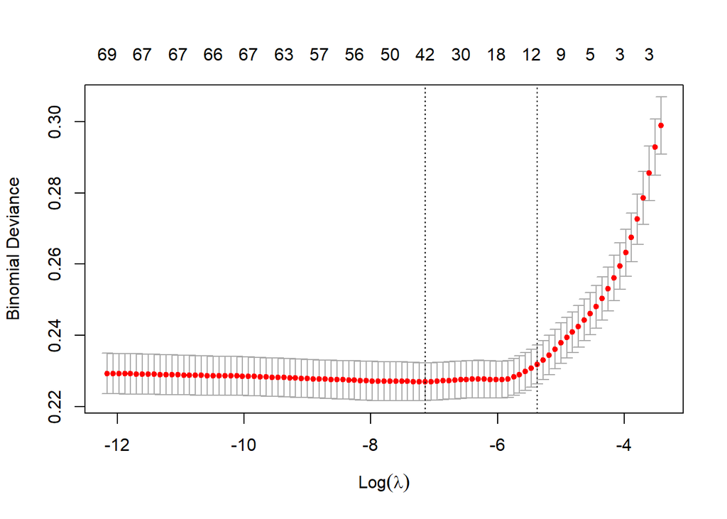

```r
set.seed(123)
fit <- glmnet(X_tr,y_tr, family='binomial',alpha = 1)

cv_lasso <- cv.glmnet(X_tr, y_tr, alpha = 1, family = "binomial")
plot(cv_lasso)
```

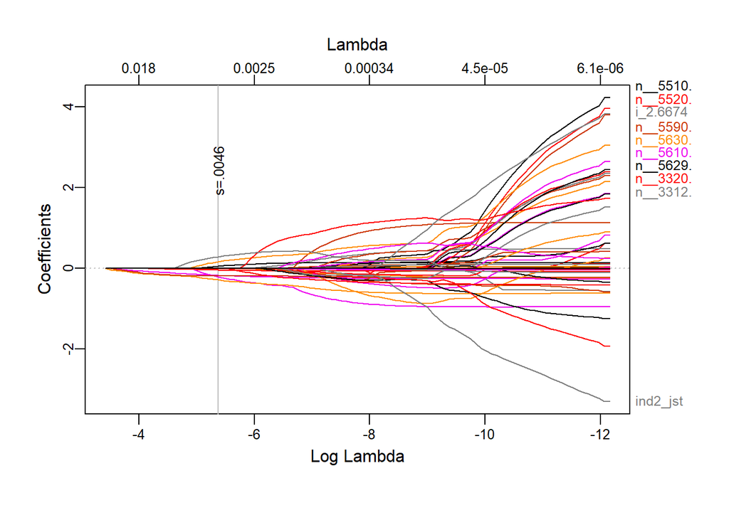

```r
s <- cv_lasso$lambda.1se

#plota gráfico do lambda em função do peso dos coeficientes das produtoras e marca lambda que utilizamos
plot_glmnet(fit, s=s)
```

```r
prob_lasso <- as.vector(predict(fit, newx = X_test, type = "response", s = s))

desempenho <- desempenho %>%
  bind_rows(tibble(prob = prob_lasso,
                     classes = ifelse(test$flag == "1", "Yes", "No"),
                     metodo = "Lasso"))

desempenho %>%
  mutate(classes = factor(classes)) %>%
  group_by(metodo) %>%
  roc_auc(classes, prob, event_level = "second") %>%
  arrange(desc(.estimate))
```

```
## # A tibble: 3 × 4
##   metodo  .metric .estimator .estimate
##   <chr>   <chr>   <chr>          <dbl>
## 1 Lasso   roc_auc binary         0.851
## 2 Ridge   roc_auc binary         0.850
## 3 Reg_Log roc_auc binary         0.840
```

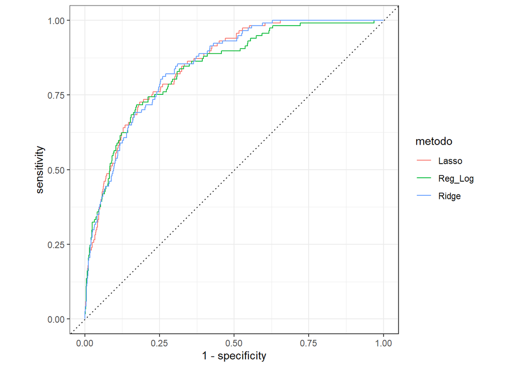

```r
desempenho %>%
  mutate(classes = factor(classes)) %>%
  group_by(metodo) %>%
  roc_curve(classes, prob, event_level = "second") %>%
  autoplot()
```